# Raw Data Profiling — Findings

**DSA Statement of Reasons data · TikTok vs X**

This notebook walks through every key finding from the column quality check, grouped by theme. All numbers are derived from `temp/profiling_output/`.

> **Coverage:** TikTok = sample of 20 files (15.4M rows, Jan–Nov 2025) out of 1,197 files / 51.5 GB.  
> X = full dataset (670k rows, 43 MB).

```python
import polars as pl
import matplotlib.pyplot as plt
import matplotlib.patches as mpatches
import numpy as np
from pathlib import Path

# Show all rows, full column names, wider strings in Polars tables
pl.Config.set_tbl_rows(-1)
pl.Config.set_tbl_cols(-1)
pl.Config.set_fmt_str_lengths(150)
pl.Config.set_tbl_width_chars(300)

OUT = Path(r'c:\Users\MoZa\OneDrive - Universität Paderborn\0_UPB\BA\Repo\Bachelor-Arbeit\temp\profiling_output')
SAVE = OUT
C = {'tiktok': '#EE1D52', 'x': '#1DA1F2'}

tt_null = pl.read_csv(OUT / 'tiktok_04_null_empty.csv')
x_null  = pl.read_csv(OUT / 'x_04_null_empty.csv')
tt_card = pl.read_csv(OUT / 'tiktok_05_cardinality.csv')
x_card  = pl.read_csv(OUT / 'x_05_cardinality.csv')
tt_topn = pl.read_csv(OUT / 'tiktok_06_topn_values.csv')
x_topn  = pl.read_csv(OUT / 'x_06_topn_values.csv')
tt_str  = pl.read_csv(OUT / 'tiktok_07_string_stats.csv')
x_str   = pl.read_csv(OUT / 'x_07_string_stats.csv')

def topn(df, col): return df.filter(pl.col('column') == col).sort('rank')
def bar(ax, df, col, color, pct_col='pct'):
    sub = topn(df, col)
    vals = sub[pct_col].to_list()
    labels = [str(v)[:55] for v in sub['value'].to_list()]
    y = np.arange(len(labels))
    ax.barh(y, vals, color=color, alpha=0.85)
    ax.set_yticks(y); ax.set_yticklabels(labels, fontsize=8)
    ax.invert_yaxis()

print('Data loaded.')
```

```
Data loaded.
```

## 1 Dataset Overview

Both platforms submit data in the same DSA Statement of Reasons (SoR) schema with **37 columns**. Despite the shared schema, the two datasets differ dramatically in size, volume, and how they use each field.

```python
overview = pl.DataFrame([
    {'platform': 'TikTok', 'files_on_disk': 1197, 'size_gb': 51.5,
     'rows_profiled': 15_439_990, 'coverage': 'sample 20 files', 'columns': 37},
    {'platform': 'X',      'files_on_disk': 291,  'size_gb': 0.04,
     'rows_profiled': 670_093,    'coverage': 'full dataset',    'columns': 37},
])
print(overview)
```

```
shape: (2, 6)
┌──────────┬───────────────┬─────────┬───────────────┬─────────────────┬─────────┐
│ platform ┆ files_on_disk ┆ size_gb ┆ rows_profiled ┆ coverage        ┆ columns │
│ ---      ┆ ---           ┆ ---     ┆ ---           ┆ ---             ┆ ---     │
│ str      ┆ i64           ┆ f64     ┆ i64           ┆ str             ┆ i64     │
╞══════════╪═══════════════╪═════════╪═══════════════╪═════════════════╪═════════╡
│ TikTok   ┆ 1197          ┆ 51.5    ┆ 15439990      ┆ sample 20 files ┆ 37      │
│ X        ┆ 291           ┆ 0.04    ┆ 670093        ┆ full dataset    ┆ 37      │
└──────────┴───────────────┴─────────┴───────────────┴─────────────────┴─────────┘
```

## 2 Missing Data

### 2.1 Columns that are 100% empty

These columns exist in the schema but contain **nothing** — every single value is null.  
They carry zero analytical value and should be dropped before any analysis.

```python
tt_100 = tt_null.filter(pl.col('total_missing_pct') == 100)['column'].to_list()
x_100  = x_null.filter(pl.col('total_missing_pct') == 100)['column'].to_list()
shared_100 = sorted(set(tt_100) & set(x_100))

print(f'TikTok — {len(tt_100)} columns at 100% missing:')
for c in sorted(tt_100): print(f'  {c}')
print(f'\nX — {len(x_100)} columns at 100% missing:')
for c in sorted(x_100): print(f'  {c}')
print(f'\nShared empty columns ({len(shared_100)}): {shared_100}')
```

```
TikTok — 12 columns at 100% missing:
  account_type
  category_addition
  category_specification
  category_specification_other
  content_language
  decision_ground_reference_url
  decision_monetary
  decision_monetary_other
  end_date_account_restriction
  end_date_monetary_restriction
  incompatible_content_illegal
  source_identity

X — 14 columns at 100% missing:
  account_type
  content_language
  content_type_other
  decision_ground_reference_url
  decision_monetary
  decision_monetary_other
  end_date_account_restriction
  end_date_monetary_restriction
  end_date_service_restriction
  end_date_visibility_restriction
  incompatible_content_explanation
  incompatible_content_ground
  incompatible_content_illegal
  source_identity

Shared empty columns (9): ['account_type', 'content_language', 'decision_ground_reference_url', 'decision_monetary', 'decision_monetary_other', 'end_date_account_restriction', 'end_date_monetary_restriction', 'incompatible_content_illegal', 'source_identity']
```

### 2.2 Columns with partial but severe missingness

These columns are *present* but mostly null — useful only for the minority of rows where they are filled.

```python
threshold = 10  # % missing
print('TikTok — columns with >10% missing (excluding 100%)')
print(tt_null.filter(
    (pl.col('total_missing_pct') > threshold) & (pl.col('total_missing_pct') < 100)
).select(['column','null_pct','total_missing_pct']).sort('total_missing_pct', descending=True))

print('\nX — columns with >10% missing (excluding 100%)')
print(x_null.filter(
    (pl.col('total_missing_pct') > threshold) & (pl.col('total_missing_pct') < 100)
).select(['column','null_pct','total_missing_pct']).sort('total_missing_pct', descending=True))
```

```
TikTok — columns with >10% missing (excluding 100%)
shape: (8, 3)
┌─────────────────────────────────┬──────────┬───────────────────┐
│ column                          ┆ null_pct ┆ total_missing_pct │
│ ---                             ┆ ---      ┆ ---               │
│ str                             ┆ f64      ┆ f64               │
╞═════════════════════════════════╪══════════╪═══════════════════╡
│ illegal_content_legal_ground    ┆ 99.99    ┆ 99.99             │
│ illegal_content_explanation     ┆ 99.99    ┆ 99.99             │
│ end_date_visibility_restriction ┆ 99.67    ┆ 99.67             │
│ decision_provision              ┆ 99.66    ┆ 99.66             │
│ end_date_service_restriction    ┆ 99.66    ┆ 99.66             │
│ decision_account                ┆ 99.34    ┆ 99.34             │
│ content_type_other              ┆ 97.24    ┆ 97.24             │
│ decision_visibility_other       ┆ 58.41    ┆ 58.41             │
└─────────────────────────────────┴──────────┴───────────────────┘

X — columns with >10% missing (excluding 100%)
shape: (5, 3)
┌──────────────────────────────┬──────────┬───────────────────┐
│ column                       ┆ null_pct ┆ total_missing_pct │
│ ---                          ┆ ---      ┆ ---               │
│ str                          ┆ f64      ┆ f64               │
╞══════════════════════════════╪══════════╪═══════════════════╡
│ category_addition            ┆ 99.98    ┆ 99.98             │
│ category_specification_other ┆ 83.33    ┆ 83.33             │
│ decision_account             ┆ 72.63    ┆ 72.63             │
│ category_specification       ┆ 32.52    ┆ 32.52             │
│ decision_provision           ┆ 31.54    ┆ 31.54             │
└──────────────────────────────┴──────────┴───────────────────┘
```

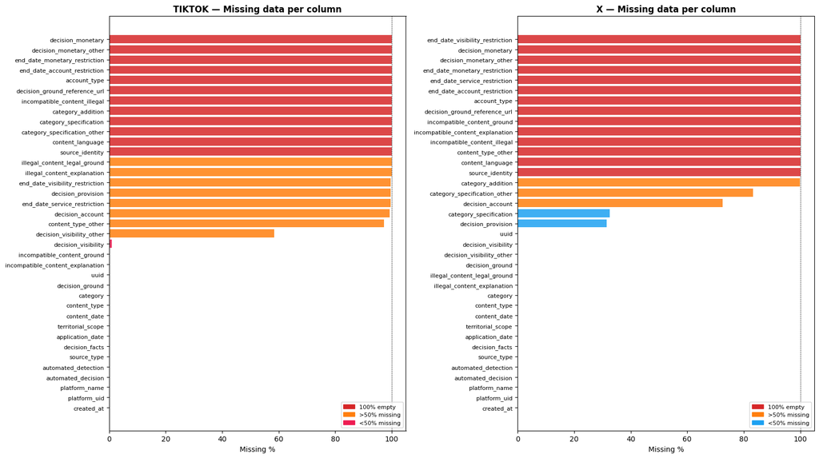

```python
fig, axes = plt.subplots(1, 2, figsize=(16, 9))
for ax, (name, df) in zip(axes, [('tiktok', tt_null), ('x', x_null)]):
    ds = df.sort('total_missing_pct', descending=True)
    cols = ds['column'].to_list()
    vals = ds['total_missing_pct'].to_list()
    colors = ['#d62728' if v == 100 else '#ff7f0e' if v > 50 else C[name] for v in vals]
    y = np.arange(len(cols))
    ax.barh(y, vals, color=colors, alpha=0.85)
    ax.set_yticks(y); ax.set_yticklabels(cols, fontsize=8)
    ax.set_xlabel('Missing %'); ax.set_xlim(0, 105)
    ax.set_title(f'{name.upper()} — Missing data per column', fontweight='bold')
    ax.axvline(100, color='black', lw=0.5, ls='--')
    ax.invert_yaxis()
    red = mpatches.Patch(color='#d62728', label='100% empty')
    org = mpatches.Patch(color='#ff7f0e', label='>50% missing')
    blu = mpatches.Patch(color=C[name],   label='<50% missing')
    ax.legend(handles=[red, org, blu], fontsize=8, loc='lower right')
plt.tight_layout()
plt.savefig(SAVE / 'findings_missing.png', dpi=130, bbox_inches='tight')
plt.show()
```

**Interpretation.**

- **Monetary decision fields** (`decision_monetary`, `decision_monetary_other`, `end_date_monetary_restriction`) are 100% empty in *both* platforms — neither TikTok nor X issued any monetary restrictions in this period.
- **End-date fields** (`end_date_visibility_restriction`, `end_date_service_restriction`, `end_date_account_restriction`) are effectively null everywhere, indicating that restrictions are applied without a stated end date — i.e., permanent or indefinite.
- TikTok's `decision_account` is 99.34% null: account-level actions are rare; almost all decisions target content.
- X's `decision_account` is 72.63% null — account actions (suspensions, terminations) are far more central to X's enforcement than TikTok's.

## 3 Decision Ground — The Biggest Structural Difference

The `decision_ground` field encodes whether a decision was taken for *illegal content* or *incompatible (policy-violating) content*.  
This is one of the most important columns for comparative analysis — and the two platforms are **polar opposites**.

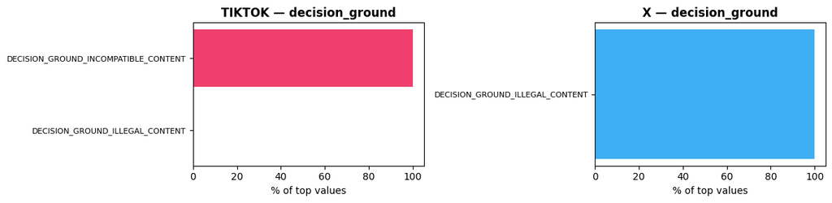

```python
fig, axes = plt.subplots(1, 2, figsize=(12, 3))
for ax, (name, df) in zip(axes, [('tiktok', tt_topn), ('x', x_topn)]):
    bar(ax, df, 'decision_ground', C[name])
    ax.set_xlabel('% of top values'); ax.set_title(f'{name.upper()} — decision_ground', fontweight='bold')
plt.tight_layout()
plt.savefig(SAVE / 'findings_decision_ground.png', dpi=130, bbox_inches='tight')
plt.show()
```

**Finding.**

- **TikTok:** 99.99% of decisions are `DECISION_GROUND_INCOMPATIBLE_CONTENT` — own platform policy violations. Only 0.01% are for illegal content under EU law.
- **X:** 100% of decisions are `DECISION_GROUND_ILLEGAL_CONTENT` — every single entry cites an EU legal basis.

This is not a data quality issue but a fundamental reporting difference: X reports *only* illegal-content decisions to the DSA register, whereas TikTok reports the vast majority of its routine policy enforcement. This has major implications for cross-platform comparisons — the datasets are measuring different enforcement populations.

## 4 Automation

`automated_detection` and `automated_decision` describe whether AI/automation was involved in flagging and deciding.

```
shape: (8, 4)
┌──────────┬─────────────────────┬──────────────────────────────────┬───────┐
│ platform ┆ column              ┆ value                            ┆ pct   │
│ ---      ┆ ---                 ┆ ---                              ┆ ---   │
│ str      ┆ str                 ┆ str                              ┆ f64   │
╞══════════╪═════════════════════╪══════════════════════════════════╪═══════╡
│ tiktok   ┆ automated_detection ┆ Yes                              ┆ 98.99 │
│ tiktok   ┆ automated_detection ┆ No                               ┆ 1.01  │
│ tiktok   ┆ automated_decision  ┆ AUTOMATED_DECISION_FULLY         ┆ 95.88 │
│ tiktok   ┆ automated_decision  ┆ AUTOMATED_DECISION_NOT_AUTOMATED ┆ 4.12  │
│ tiktok   ┆ automated_decision  ┆ AUTOMATED_DECISION_PARTIALLY     ┆ 0.0   │
│ x        ┆ automated_detection ┆ No                               ┆ 100.0 │
│ x        ┆ automated_decision  ┆ AUTOMATED_DECISION_NOT_AUTOMATED ┆ 98.55 │
│ x        ┆ automated_decision  ┆ AUTOMATED_DECISION_FULLY         ┆ 1.45  │
└──────────┴─────────────────────┴──────────────────────────────────┴───────┘
```

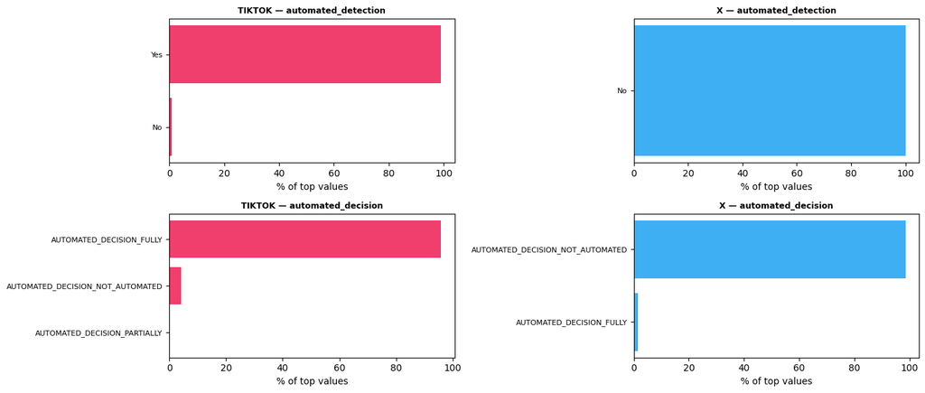

```python
auto_rows = []
for name, df in [('tiktok', tt_topn), ('x', x_topn)]:
    for col in ['automated_detection', 'automated_decision']:
        for row in topn(df, col).iter_rows(named=True):
            auto_rows.append({'platform': name, 'column': col,
                              'value': row['value'], 'pct': row['pct']})
print(pl.DataFrame(auto_rows))

fig, axes = plt.subplots(2, 2, figsize=(14, 6))
for col_i, col in enumerate(['automated_detection', 'automated_decision']):
    for plat_i, (name, df) in enumerate([('tiktok', tt_topn), ('x', x_topn)]):
        ax = axes[col_i][plat_i]
        bar(ax, df, col, C[name])
        ax.set_xlabel('% of top values')
        ax.set_title(f'{name.upper()} — {col}', fontweight='bold', fontsize=9)
plt.tight_layout()
plt.savefig(SAVE / 'findings_automation.png', dpi=130, bbox_inches='tight')
plt.show()
```

**Finding.**

## 5 Content Category Distribution

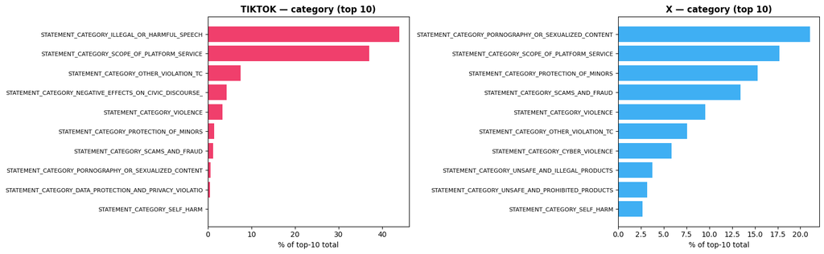

```python
fig, axes = plt.subplots(1, 2, figsize=(16, 5))
for ax, (name, df) in zip(axes, [('tiktok', tt_topn), ('x', x_topn)]):
    bar(ax, df, 'category', C[name])
    ax.set_xlabel('% of top-10 total')
    ax.set_title(f'{name.upper()} — category (top 10)', fontweight='bold')
plt.tight_layout()
plt.savefig(SAVE / 'findings_category.png', dpi=130, bbox_inches='tight')
plt.show()
```

**Finding.**

- **TikTok top categories:** Illegal/Harmful Speech (44%), Scope of Platform Service (37%), Other ToC violation (7.5%), Civic Discourse/Elections (4.3%), Violence (3.4%).
- **X top categories:** Pornography/Sexualized Content (21%), Scope of Service (18%), Protection of Minors (15%), Scams & Fraud (13%), Violence (10%).

TikTok's dominant category is speech-related; X's is sexualized content and child protection. The category distributions are structurally different, reflecting each platform's enforcement focus and the reporting scope difference identified in Section 3.

## 6 Decision Type — What Action Was Taken

`decision_visibility`, `decision_provision`, and `decision_account` together describe what happened to the content or account.

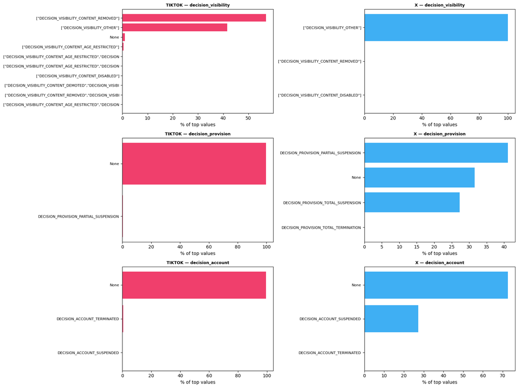

```python
fig, axes = plt.subplots(3, 2, figsize=(16, 12))
for row_i, col in enumerate(['decision_visibility', 'decision_provision', 'decision_account']):
    for col_i, (name, df) in enumerate([('tiktok', tt_topn), ('x', x_topn)]):
        ax = axes[row_i][col_i]
        bar(ax, df, col, C[name])
        ax.set_xlabel('% of top values')
        ax.set_title(f'{name.upper()} — {col}', fontweight='bold', fontsize=9)
plt.tight_layout()
plt.savefig(SAVE / 'findings_decision_type.png', dpi=130, bbox_inches='tight')
plt.show()
```

**Finding.**

- **TikTok `decision_visibility`:** 57% content removed, 42% DECISION_VISIBILITY_OTHER (mostly FYF demotion — "not eligible for For You feed"). Hard removal is the majority action.
- **X `decision_visibility`:** 99.99% DECISION_VISIBILITY_OTHER — X almost never removes content outright; it labels it (NSFW, Bounce = soft demotion).
- **Account actions:** TikTok's `decision_account` is 99.34% null (near-zero account actions). X has 27.3% account suspensions and 0.12% terminations — account-level enforcement is central to X's approach.
- **`decision_provision`:** TikTok uses partial suspension rarely (0.34%); X splits across partial suspension/Bounce (41%), null (32%), and total suspension (27%).

## 7 Territorial Scope — Geographic Targeting

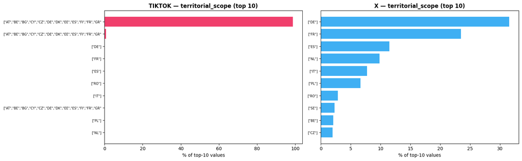

```python
fig, axes = plt.subplots(1, 2, figsize=(16, 5))
for ax, (name, df) in zip(axes, [('tiktok', tt_topn), ('x', x_topn)]):
    sub = topn(df, 'territorial_scope')
    labels = [str(v)[:60] for v in sub['value'].to_list()]
    vals   = sub['pct'].to_list()
    y = np.arange(len(labels))
    ax.barh(y, vals, color=C[name], alpha=0.85)
    ax.set_yticks(y); ax.set_yticklabels(labels, fontsize=7)
    ax.set_xlabel('% of top-10 values')
    ax.set_title(f'{name.upper()} — territorial_scope (top 10)', fontweight='bold')
    ax.invert_yaxis()
plt.tight_layout()
plt.savefig(SAVE / 'findings_territorial.png', dpi=130, bbox_inches='tight')
plt.show()
```

**Finding.**

## 8 Source Type — Who Triggered the Decision

```python
for name, df in [('TikTok', tt_topn), ('X', x_topn)]:
    print(f'--- {name} source_type ---')
    print(topn(df, 'source_type').select(['value','count','pct']))
    print()

print('--- TikTok decision_facts (who/how initiated) ---')
print(topn(tt_topn, 'decision_facts').select(['value','pct']))
print()
print('--- X decision_facts ---')
print(topn(x_topn, 'decision_facts').select(['value','pct']))
```

```
--- TikTok source_type ---
shape: (4, 3)
┌────────────────────────────────┬──────────┬───────┐
│ value                          ┆ count    ┆ pct   │
│ ---                            ┆ ---      ┆ ---   │
│ str                            ┆ i64      ┆ f64   │
╞════════════════════════════════╪══════════╪═══════╡
│ SOURCE_VOLUNTARY               ┆ 15437671 ┆ 99.98 │
│ SOURCE_ARTICLE_16              ┆ 2179     ┆ 0.01  │
│ SOURCE_TYPE_OTHER_NOTIFICATION ┆ 136      ┆ 0.0   │
│ SOURCE_TRUSTED_FLAGGER         ┆ 4        ┆ 0.0   │
└────────────────────────────────┴──────────┴───────┘

--- X source_type ---
shape: (1, 3)
┌────────────────────────────────┬────────┬───────┐
│ value                          ┆ count  ┆ pct   │
│ ---                            ┆ ---    ┆ ---   │
│ str                            ┆ i64    ┆ f64   │
╞════════════════════════════════╪════════╪═══════╡
│ SOURCE_TYPE_OTHER_NOTIFICATION ┆ 670093 ┆ 100.0 │
└────────────────────────────────┴────────┴───────┘

--- TikTok decision_facts (who/how initiated) ---
shape: (8, 2)
┌──────────────────────────────────────────────────────────────────────────────────────────────────┬───────┐
│ value                                                                                            ┆ pct   │
│ ---                                                                                              ┆ ---   │
│ str                                                                                              ┆ f64   │
╞══════════════════════════════════════════════════════════════════════════════════════════════════╪═══════╡
│ The decision was taken pursuant to own-initiative investigations.                                ┆ 98.08 │
│ The decision was taken pursuant to own-initiative investigations                                 ┆ 1.23  │
│ The decision was taken in response to a report alleging a violation of our Community Guidelines. ┆ 0.66  │
│ The decision was taken in response to a report alleging a violation of our Advertising Policies. ┆ 0.01  │
│ The decision was taken in response to an illegal content report under Art. 16 DSA.               ┆ 0.01  │
│ We have taken this decision based on a report under the ElDigital Services Act.                  ┆ 0.0   │
│ The decision was taken in response to a report from a Trusted Flagger under Art. 22 DSA.         ┆ 0.0   │
│ The decision was taken in response to a report from a third party.                               ┆ 0.0   │
└──────────────────────────────────────────────────────────────────────────────────────────────────┴───────┘

--- X decision_facts ---
shape: (10, 2)
┌─────────────────────────────────────────────────────────────────────────────┬───────┐
│ value                                                                       ┆ pct   │
│ ---                                                                         ┆ ---   │
│ str                                                                         ┆ f64   │
╞═════════════════════════════════════════════════════════════════════════════╪═══════╡
│ Decision - action Bounce triggered manually by an agent                     ┆ 40.1  │
│ Decision - action Nsfw triggered manually by an agent                       ┆ 30.96 │
│ Decision - action Suspend triggered manually by an agent                    ┆ 27.26 │
│ Decision - action Bounce triggered by the system with no human intervention ┆ 0.99  │
│ Decision - action Nsfw triggered by the system with no human intervention   ┆ 0.46  │
│ Decision - action Deactivate triggered manually by an agent                 ┆ 0.12  │
│ Decision - action Ban triggered manually by an agent                        ┆ 0.08  │
│ Decision - action Unban triggered manually by an agent                      ┆ 0.02  │
│ Decision - action RemoveVerifiedType triggered manually by an agent         ┆ 0.0   │
│ Decision - action DeleteBirdwatchNote triggered manually by an agent        ┆ 0.0   │
└─────────────────────────────────────────────────────────────────────────────┴───────┘
```

**Finding.**

**Data quality note:** TikTok's `decision_facts` has a near-duplicate value with and without a trailing period:

> `"The decision was taken pursuant to own-initiative investigations."` (98.08%) `"The decision was taken pursuant to own-initiative investigations"` (1.23%)

These are semantically identical — a minor inconsistency worth normalizing.

## 9 Content Type

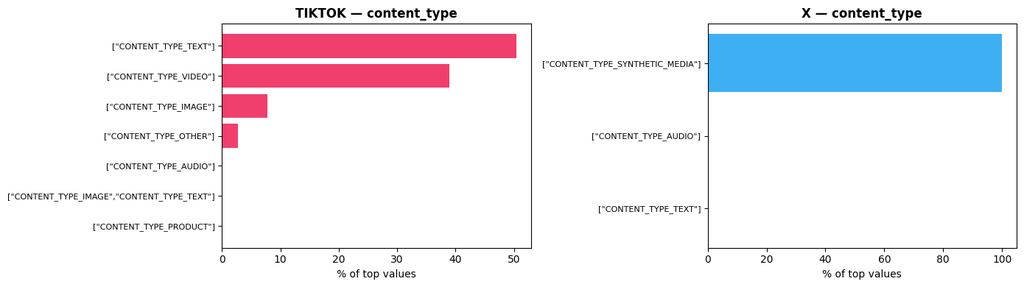

```python
fig, axes = plt.subplots(1, 2, figsize=(14, 4))
for ax, (name, df) in zip(axes, [('tiktok', tt_topn), ('x', x_topn)]):
    bar(ax, df, 'content_type', C[name])
    ax.set_xlabel('% of top values')
    ax.set_title(f'{name.upper()} — content_type', fontweight='bold')
plt.tight_layout()
plt.savefig(SAVE / 'findings_content_type.png', dpi=130, bbox_inches='tight')
plt.show()
```

**Finding.**

- **TikTok:** Content is split across text (50%), video (39%), and image (8%) — reflecting the platform's multi-format nature. Comments and captions count as text.
- **X:** 99.97% `CONTENT_TYPE_SYNTHETIC_MEDIA` — an unusual classification. In X's DSA reporting, accounts and their associated content appear to be filed as synthetic media, likely because account-level actions affect a user's entire profile rather than a specific post. This is a platform-specific encoding choice, not a reflection of AI-generated content prevalence.

## 10 String Quality — Lengths, Truncation, Whitespace

```python
print('=== TikTok string lengths (sorted by max length) ===')
print(tt_str.filter(pl.col('len_max') > 0)
      .sort('len_max', descending=True)
      .select(['column','len_min','len_max','len_mean','whitespace_anomaly_count']))

print('\n=== X string lengths ===')
print(x_str.filter(pl.col('len_max') > 0)
      .sort('len_max', descending=True)
      .select(['column','len_min','len_max','len_mean','whitespace_anomaly_count']))

print('\nWhitespace anomalies (leading/trailing spaces):')
tt_ws = tt_str.filter(pl.col('whitespace_anomaly_count') > 0)
x_ws  = x_str.filter(pl.col('whitespace_anomaly_count') > 0)
print(f'  TikTok: {len(tt_ws)} columns affected → {tt_ws["column"].to_list()}')
print(f'  X:      {len(x_ws)} columns affected → {x_ws["column"].to_list()}')
```

```
=== TikTok string lengths (sorted by max length) ===
shape: (20, 5)
┌──────────────────────────────────┬─────────┬─────────┬──────────┬──────────────────────────┐
│ column                           ┆ len_min ┆ len_max ┆ len_mean ┆ whitespace_anomaly_count │
│ ---                              ┆ ---     ┆ ---     ┆ ---      ┆ ---                      │
│ str                              ┆ i64     ┆ i64     ┆ f64      ┆ i64                      │
╞══════════════════════════════════╪═════════╪═════════╪══════════╪══════════════════════════╡
│ illegal_content_explanation      ┆ 5       ┆ 2000    ┆ 41.74    ┆ 0                        │
│ incompatible_content_explanation ┆ 3       ┆ 2000    ┆ 559.03   ┆ 0                        │
│ illegal_content_legal_ground     ┆ 10      ┆ 500     ┆ 31.67    ┆ 0                        │
│ incompatible_content_ground      ┆ 3       ┆ 500     ┆ 25.48    ┆ 0                        │
│ decision_visibility_other        ┆ 3       ┆ 193     ┆ 59.5     ┆ 0                        │
│ territorial_scope                ┆ 2       ┆ 151     ┆ 145.53   ┆ 0                        │
│ decision_visibility              ┆ 29      ┆ 112     ┆ 34.84    ┆ 0                        │
│ decision_facts                   ┆ 64      ┆ 96      ┆ 65.2     ┆ 0                        │
│ category                         ┆ 27      ┆ 67      ┆ 43.77    ┆ 0                        │
│ content_type                     ┆ 21      ┆ 42      ┆ 21.5     ┆ 0                        │
│ decision_provision               ┆ 37      ┆ 37      ┆ 37.0     ┆ 0                        │
│ uuid                             ┆ 36      ┆ 36      ┆ 36.0     ┆ 0                        │
│ decision_ground                  ┆ 31      ┆ 36      ┆ 36.0     ┆ 0                        │
│ automated_decision               ┆ 24      ┆ 32      ┆ 24.33    ┆ 0                        │
│ source_type                      ┆ 16      ┆ 30      ┆ 16.0     ┆ 0                        │
│ decision_account                 ┆ 26      ┆ 27      ┆ 27.0     ┆ 0                        │
│ content_type_other               ┆ 4       ┆ 27      ┆ 13.1     ┆ 0                        │
│ platform_uid                     ┆ 19      ┆ 19      ┆ 19.0     ┆ 0                        │
│ platform_name                    ┆ 6       ┆ 6       ┆ 6.0      ┆ 0                        │
│ automated_detection              ┆ 2       ┆ 3       ┆ 2.99     ┆ 0                        │
└──────────────────────────────────┴─────────┴─────────┴──────────┴──────────────────────────┘

=== X string lengths ===
shape: (20, 5)
┌──────────────────────────────┬─────────┬─────────┬──────────┬──────────────────────────┐
│ column                       ┆ len_min ┆ len_max ┆ len_mean ┆ whitespace_anomaly_count │
│ ---                          ┆ ---     ┆ ---     ┆ ---      ┆ ---                      │
│ str                          ┆ i64     ┆ i64     ┆ f64      ┆ i64                      │
╞══════════════════════════════╪═════════╪═════════╪══════════╪══════════════════════════╡
│ illegal_content_legal_ground ┆ 2       ┆ 101     ┆ 15.53    ┆ 0                        │
│ illegal_content_explanation  ┆ 2       ┆ 101     ┆ 15.53    ┆ 0                        │
│ decision_facts               ┆ 52      ┆ 75      ┆ 54.94    ┆ 0                        │
│ category                     ┆ 27      ┆ 67      ┆ 41.01    ┆ 0                        │
│ category_specification_other ┆ 20      ┆ 66      ┆ 65.97    ┆ 0                        │
│ category_specification       ┆ 17      ┆ 57      ┆ 28.27    ┆ 0                        │
│ category_addition            ┆ 31      ┆ 56      ┆ 42.09    ┆ 0                        │
│ platform_uid                 ┆ 35      ┆ 41      ┆ 41.0     ┆ 0                        │
│ decision_visibility          ┆ 29      ┆ 40      ┆ 29.0     ┆ 0                        │
│ decision_provision           ┆ 35      ┆ 37      ┆ 36.2     ┆ 0                        │
│ uuid                         ┆ 36      ┆ 36      ┆ 36.0     ┆ 0                        │
│ content_type                 ┆ 21      ┆ 32      ┆ 32.0     ┆ 0                        │
│ automated_decision           ┆ 24      ┆ 32      ┆ 31.88    ┆ 0                        │
│ decision_ground              ┆ 31      ┆ 31      ┆ 31.0     ┆ 0                        │
│ source_type                  ┆ 30      ┆ 30      ┆ 30.0     ┆ 0                        │
│ decision_account             ┆ 26      ┆ 27      ┆ 26.0     ┆ 0                        │
│ decision_visibility_other    ┆ 3       ┆ 22      ┆ 5.65     ┆ 0                        │
│ platform_name                ┆ 1       ┆ 20      ┆ 1.04     ┆ 0                        │
│ territorial_scope            ┆ 6       ┆ 6       ┆ 6.0      ┆ 0                        │
│ automated_detection          ┆ 2       ┆ 2       ┆ 2.0      ┆ 0                        │
└──────────────────────────────┴─────────┴─────────┴──────────┴──────────────────────────┘

Whitespace anomalies (leading/trailing spaces):
  TikTok: 0 columns affected → []
  X:      0 columns affected → []
```

**Finding.**

- **Truncation at 2000 chars:** TikTok's `incompatible_content_explanation` and `illegal_content_explanation` both have `len_max = 2000`. The mean of 559 chars with a hard ceiling strongly suggests a database truncation limit. Long explanations are cut off.
- **Truncation at 500 chars:** `incompatible_content_ground` (max 500) and `illegal_content_legal_ground` (max 500) show the same pattern.
- **X territorial scope is always exactly 6 chars** (`len_min = len_max = 6`), confirming single-country ISO codes like `["DE"]` — consistent with the territorial scope finding in Section 7.
- **TikTok uuid is always exactly 36 chars** — standard UUID v4 format, no anomalies.
- **No whitespace anomalies** in either dataset — no leading/trailing spaces found.

## 11 Constant & Near-Constant Columns (Cardinality = 1)

A column with only 1 unique value adds no variation and should be excluded from analysis.

```python
tt_const = tt_card.filter(pl.col('n_unique') == 1)['column'].to_list()
x_const  = x_card.filter(pl.col('n_unique') == 1)['column'].to_list()

print(f'TikTok — {len(tt_const)} constant columns:')
for c in sorted(tt_const): print(f'  {c}')
print(f'\nX — {len(x_const)} constant columns:')
for c in sorted(x_const): print(f'  {c}')
```

```
TikTok — 11 constant columns:
  account_type
  category_addition
  category_specification
  category_specification_other
  content_language
  decision_ground_reference_url
  decision_monetary
  decision_monetary_other
  incompatible_content_illegal
  platform_name
  source_identity

X — 17 constant columns:
  account_type
  automated_detection
  content_language
  content_type_other
  decision_ground
  decision_ground_reference_url
  decision_monetary
  decision_monetary_other
  end_date_account_restriction
  end_date_monetary_restriction
  end_date_service_restriction
  end_date_visibility_restriction
  incompatible_content_explanation
  incompatible_content_ground
  incompatible_content_illegal
  source_identity
  source_type
```

**Finding.**  
Most constant columns are ones already flagged as 100% null (null itself is a single unique value).  
Notable non-null constants:

- `platform_name` = `"TikTok"` always (TikTok) — expected, not useful for analysis.
- `decision_ground` = `DECISION_GROUND_ILLEGAL_CONTENT` always (X) — confirms finding in Section 3.
- `source_type` = `SOURCE_TYPE_OTHER_NOTIFICATION` always (X) — confirms finding in Section 8.
- `automated_detection` = `No` always (X) — confirms finding in Section 4.

## 12 Identifier Integrity — UUID and Platform UID

```python
tt_uuid_uniq = tt_card.filter(pl.col('column') == 'uuid')['n_unique'][0]
x_uuid_uniq  = x_card.filter(pl.col('column') == 'uuid')['n_unique'][0]
tt_rows = tt_null.filter(pl.col('column') == 'uuid')['total_rows'][0]
x_rows  = x_null.filter(pl.col('column') == 'uuid')['total_rows'][0]

print(f'TikTok uuid: {tt_uuid_uniq:,} unique / {tt_rows:,} rows → {"OK — all unique" if tt_uuid_uniq == tt_rows else "DUPLICATES FOUND"}')
print(f'X      uuid: {x_uuid_uniq:,} unique / {x_rows:,} rows → {"OK — all unique" if x_uuid_uniq == x_rows else "DUPLICATES FOUND"}')

print('\nPlatform name variants:')
print('  X:', topn(x_topn, 'platform_name').select(['value','count','pct']))
```

```
TikTok uuid: 15,439,990 unique / 15,439,990 rows → OK — all unique
X      uuid: 670,093 unique / 670,093 rows → OK — all unique

Platform name variants:
  X: shape: (2, 3)
┌──────────────────────┬────────┬───────┐
│ value                ┆ count  ┆ pct   │
│ ---                  ┆ ---    ┆ ---   │
│ str                  ┆ i64    ┆ f64   │
╞══════════════════════╪════════╪═══════╡
│ X                    ┆ 668624 ┆ 99.78 │
│ X (formerly Twitter) ┆ 1469   ┆ 0.22  │
└──────────────────────┴────────┴───────┘
```

**Finding.**

- UUIDs are all unique in both datasets — no duplicate rows detected at the identifier level.
- X's `platform_name` has two variants: `"X"` (99.78%) and `"X (formerly Twitter)"` (0.22%). This is a minor naming inconsistency, likely reflecting a transition period in the reporting API. Should be normalized to a single value before analysis.

## 13 Summary: What to Clean Before Analysis

```python
shared_empty = sorted(set(
    tt_null.filter(pl.col('total_missing_pct') == 100)['column'].to_list()
) & set(
    x_null.filter(pl.col('total_missing_pct') == 100)['column'].to_list()
))

print('COLUMNS TO DROP (100% null in both platforms):')
for c in shared_empty: print(f'  {c}')

print('\nDATA QUALITY ISSUES TO FIX:')
issues = [
    ('Normalize',  'X.platform_name',         '"X (formerly Twitter)" → "X" (0.22% of rows)'),
    ('Normalize',  'TikTok.decision_facts',    'trailing period variant: 1.23% of rows'),
    ('Flag',       'TikTok.incompatible_content_explanation', 'truncated at 2000 chars'),
    ('Flag',       'TikTok.illegal_content_explanation',      'truncated at 2000 chars'),
    ('Flag',       'TikTok.incompatible_content_ground',      'truncated at 500 chars'),
    ('Note',       'X.content_type',           '99.97% SYNTHETIC_MEDIA — platform encoding, not actual type'),
    ('Note',       'territorial_scope',        'TikTok = multi-country arrays; X = single country — not directly comparable'),
]
for action, field, note in issues:
    print(f'  [{action}] {field}: {note}')

print('\nSCOPE DIFFERENCES (not data quality, but must be noted in analysis):')
scope = [
    'decision_ground:    TikTok = 100% incompatible content  /  X = 100% illegal content',
    'automated_decision: TikTok = 96% fully automated        /  X = 99% human decision',
    'source_type:        TikTok = 100% voluntary/proactive   /  X = 100% other notification',
    'territorial_scope:  TikTok = pan-EU bloc decisions       /  X = single-country decisions',
]
for s in scope: print(f'  {s}')
```

```
COLUMNS TO DROP (100% null in both platforms):
  account_type
  content_language
  decision_ground_reference_url
  decision_monetary
  decision_monetary_other
  end_date_account_restriction
  end_date_monetary_restriction
  incompatible_content_illegal
  source_identity

DATA QUALITY ISSUES TO FIX:
  [Normalize] X.platform_name: "X (formerly Twitter)" → "X" (0.22% of rows)
  [Normalize] TikTok.decision_facts: trailing period variant: 1.23% of rows
  [Flag] TikTok.incompatible_content_explanation: truncated at 2000 chars
  [Flag] TikTok.illegal_content_explanation: truncated at 2000 chars
  [Flag] TikTok.incompatible_content_ground: truncated at 500 chars
  [Note] X.content_type: 99.97% SYNTHETIC_MEDIA — platform encoding, not actual type
  [Note] territorial_scope: TikTok = multi-country arrays; X = single country — not directly comparable

SCOPE DIFFERENCES (not data quality, but must be noted in analysis):
  decision_ground:    TikTok = 100% incompatible content  /  X = 100% illegal content
  automated_decision: TikTok = 96% fully automated        /  X = 99% human decision
  source_type:        TikTok = 100% voluntary/proactive   /  X = 100% other notification
  territorial_scope:  TikTok = pan-EU bloc decisions       /  X = single-country decisions
```